# CS6750 HCI Notes

Author: Taichi Nakatani

## 1.1 Introduction to HCI

Interaction:

- Human
- Computer
- Task

> We might be experts at interacting with computers, but that doesn't make us experts at designing interactions between other humans and computers.

### Overview of HCI

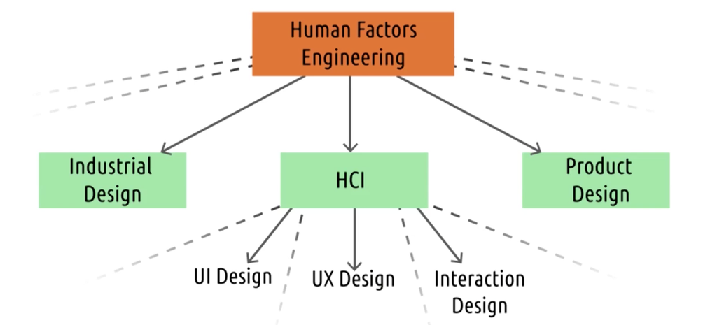

- **Human factor engineering**: Designing interactions between people and products, systems or devices.
  - Merger of engineering and psychology
- HCI vs UI Design: UI design is more concerned with on-screen interaction.
- HCI vs UX Design: UX design dicates how humans interact with computers (while HCI understand this interaction). Symbiotic relationship.

What is HCI:

- Research: needfinding, prototyping, evaluation
- Design: distributed cognition, mental models, universal design
- research/design is symbiotic

Reference:

- Richard Mander, Gitta Salomon, and Yin Yin Wong. 1992. A “pile” metaphor for supporting casual organization of information. In Proceedings of the SIGCHI Conference on Human Factors in Computing Systems (CHI '92). Association for Computing Machinery, New York, NY, USA, 627–634. https://doi.org/10.1145/142750.143055
  - How do people organize rapid flow of information in their work spaces.
  - People organized things in 'piles' of related materials. Mimic it in computer interface.

## 1.2 Introduction to CS6750

Learning goals:

1. Understand common principles in HCI
2. Understand the design life cycle
3. Understand current applications of HCI

Learning outcome: "To **design** *effective interactions* between humans and computers"

- Design: Applying known principles to a new problem.
- Design: An interative process of needfinding, prototyping, evaluating, and revising.
- Effective interactions: usability, research, change
- Between humans and computers: Not just interfaces, designing interactions.

Learning strategies:

- learning by example
- learning by doing
- learning by reflection ("you are not your user")

## 1.3 Exploring HCI

New application areas:

- Technologies: emerging technological capabilities that let us create new and interaction user interactions.
- Domains: pre-existing areas that could be significantly disrupted by computer interfaces
- Ideas: Theories about the way people interact with interfaces and the world around them.

### Technology

- Augmented Reality: Complements real world.
- Ubiquitous Computing: Computing power anywhere, anytime. IoT. Wearable technology.
- Human-robot interaction: Robot safety, societal impact, feedback/reinforcement systems
- Mobile: Limitations in compute, but ubiquitous. Challenges in replacing computers.
- Context-sensitive computing: Equipping UIs with historical, geographical, or other forms of contextual knowledge.

### Idea

- Gesture-based interaction: wrist-band motion
- Pen/touch-based interaction
- Information visualization: representing abstract data visually to help humans understand it
- Computer-supported Cooperative Work (CSCW): Using computers to support people working together.
  - Divided by TIME and PLACE

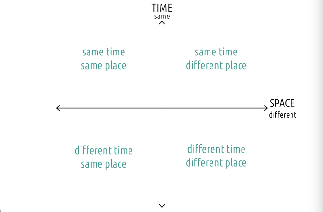

- Social Computing: How computers affect the way we interact and socialize
  - Recreating social norms within computational systems (chat interface, ppl using emojis to show emotion, etc)

### Domain

- Special needs: Prosthetics, communicating data to a blind person using sound.
- Education: Making education challenging, but not due to bad interace. "Worst thing to do is make students busy worrying about the interface instead of the subject matter itself"
- Healthcare: virtual reality, immersion therapy.
- Security: Increasing the usability of security through HCI.
- Games: good logical mapping between action & effect. Tight connection between task and interface.

## 2.1 Intro to Principles

Learning Goals:

1. Focusing on the task (not tools)
2. Role of the interface in mediating users and tasks
3. The role of the user: Processor? Predictor? Participant?
4. User experience at multiple levels

### Tips for identifying a task

1. Watch real users
2. Talk to them (what is their goals/motives)
3. Start small
4. Abstract up - work from small observations, abstract up to an understanding of the tasks they're trying to complete.
5. You are not your user

### Usefulness and Usability

- Useful: interface allows the user to achieve some task
- Usability: More important, by understanding the task it allows you to create solutions beyond standard interfaces (e.g. paper maps vs navigation systems)
  - Reduce *cognitive load*: The total mental effort being used in working memory.

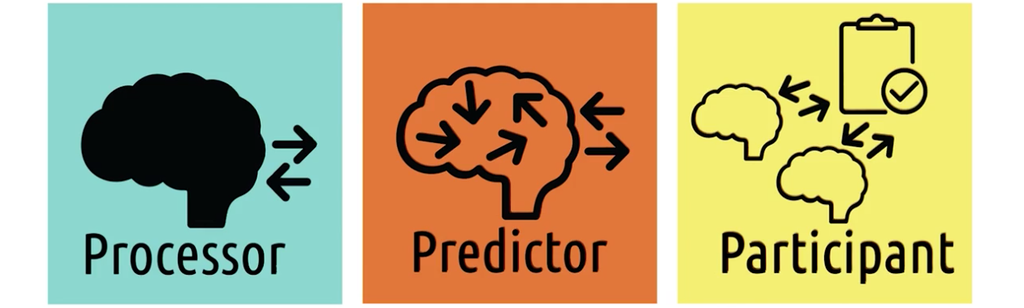

### Views of the User: Processor

- Humans as "processors": Take input in and give output out.
- Interface must fit within human limits:
  - Think of what humans can sense, store in memory, and physically do in the world.
  - "Usability" equals an interface that is *physically* usable.
- Interfaces are evaluated by quantitative experiments:
  - Numeric measurements on how quickly the user can complete a task, or react to a stimulus.
- Less emphasis placed on this view

### Views of the User: Predictor

- Humans as "predictors": We want humans to predict what will happen in the world as a result of some action they take.
- Interface must fit with their knowledge:
  - Help users learn what they don't know, and leverage what they already know.
- Evaluated by qualitative studies:
  - "Ex situ" studies (in a controlled environment)
  - Task analyses, cognitive walk-throughs to understand the user's thought
- Still focused on one user, one task.

### Views of the User: Participant

- Humans as "participant": Interface is interested in what's going on around the user (e.g. other tasks, other ppl they are interacting with).
- Interface must fit with the context: Humans must be able to interact with the system in the context where they need it.
- Evaluated by *"in-situ"* studies (studying interface + user within the real context of the task)

PPP Table

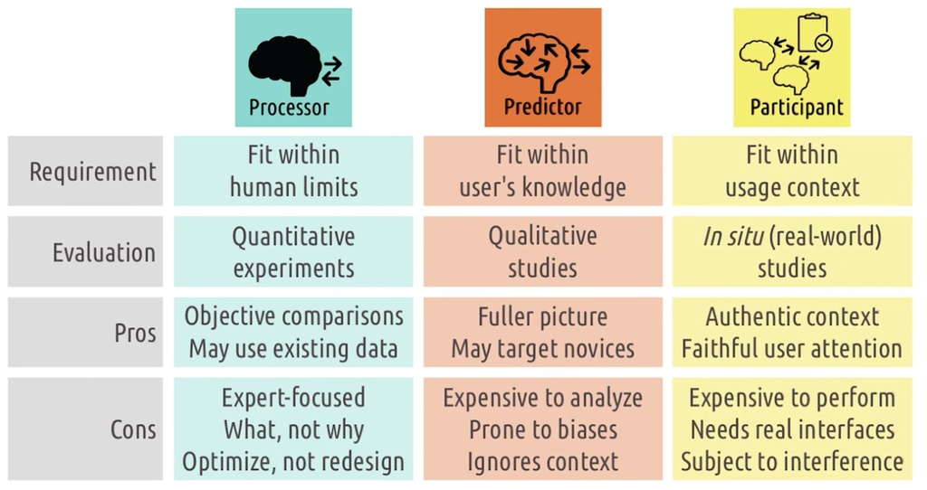

### Views of User: Schools of Thought

- Processor: From Behaviorist school. Systematic way to investigate behaviors in humans and other animals.
  - John B. Watson: Focus on observed behavior, not introspection.
  - Pavlov (dog), Skinner (operant conditiong, rats)
- Predictor: From Cognitivism. We care about what the user is predicting, ie. thinking.
  - Is knowledge inborn, or through experience (Kant, Descartes)
  - Cognitive science (50s)
  - Chomsky, Carey, Minsky, Herbert Simon, etc.
- Participant: Functionalism (Psychology), Systems (Psychology). More based from HCI.
  - Cares about environment of the user.
  - Edwin Hutchins, Lucy Suchman, etc.

### Designing with Three Views

Test Case: Tesla interface screen

Processor model: Strictly observe user's behavior (e.g. timing)

- Pros: May use existing data, enables objective comparisons (ie. text vs voice wrt speed),
- Cons: Don't find reasons for differences. Can't differentiate by expertise (power user vs novice). Helps optimize but not redesign.

Predictor model:

- Pros:
  - More complete picture of interaction: Ask users for input (e.g. interviews / focus groups, show prototypes and see what they think). Why users use different interface at different times (voice vs text).
  - Targets different levels of expertise: Ranging from power users to novice.
- Cons:
  - Analysis may be expensive (going through transcripts, analysis takes time).
  - Analysis is subject to biases: Analyst can have bias in interpreting interview data.
  - Ignores broader interaction context: Only focuses on interface, not the real authentic environment in which they are using that interface.

Participant model:

- Pros:
  - Evaluates interaction in context: Notice how users may get distracted.
  - Captures authentic user attention
- Cons:
  - Expensive to perform and analyze
  - Requires real, functional interfaces (not prototypes). Hard to use this model when getting started with a new design task.
  - Subject to more uncontrollable variables.

Takeaway: **We'll use all of these models at different times and in different contexts**

> We might start with a participant model where we just ride around with users watching what they do.

> Based on that, we might observe that they spend a lot of time fumbling around to return to the same few locations.

> So, then we might redesign an interface to include some kind of ‘bookmarking’ system, and present it to users in interviews.

> There, they might tell us that they like the design, but further note that they don’t need a long list of bookmarks -- they really only need work and home.

> Based on that, we might then design an interface where a simple swipe takes them to work or home. Then, we might test that with users to see how much more efficiently they’re able to start navigation when these kinds of shortcuts are provided.

> The results of each design phase inform the next, and different phases call for different types of evaluation, which echo different models of the user.

### Good Design, Bad Design

- Good Design: A GPS system that warns you 20 seconds before you need to make a turn
- Bad Design: A GPS system that warns you 2 seconds before you need to make a turn
1. If you view the user just as a **sensory processor**, you might think that we need only alert the user a second before they need to turn: after all, human reaction time is less than a second.
2. If you view the user as a **predictor**, you understand that they need time to slow the car down and make the turn, so they need a few more seconds to actually execute the action of turning after being alerted about the upcoming turn.
3. And if you view the user as a **participant**, you understand that this is happening while they’re going 50 miles an hour down the road with a screaming toddler in the back seat trying to merge with a driver on a cell phone and another eating a cheeseburger.

### Reflections: Views of the User

- Bad processor model: Time tracking by manual entry, doesn't take realistic view of human's role in the system.
- Good predictor model: Ed UI (interface to show upcoming lessons, playback bar), takes cognitive load off user so they can focus on learning.
- Good participant model: Sleep tracking apps. It monitors my sleep cycles, rings at the optimal time, and tracks my sleep patterns to make recommendations.

### User Experience - Sans Design

- By my definition, user experience design is attempting to create systems that dictate how the user will experience them.
- User experience on its own, however, is a phenomenon that emerges out of interactions between users and tasks via interfaces.
- It goes beyond the simple interaction of the user with the interface to accomplish the task and touches on the emotional, personal, or more experiential elements of the relationship.
- We can build this idea as an expanding understanding of the scope of what defines the ‘user experience’.

### Design Challenge: Morgan on the Street

So, keeping in mind everything we’ve talked about, let’s design something for Morgan. Morgan walks to work. She likes to listen to audiobooks, mostly non-fiction. But she doesn’t just want to listen, she wants to be able to take notes and leave bookmarks as well. What would designing for her look like from the perspectives of viewing her as a processor, a predictor, and a participant?

1. Processor: What is communicated, when and how.
   - Look at what information is communicated to Morgan, when and how.
2. Predictor: How the interface meshes with Morgan's immediate needs.
   - Look at how the interface meshes with Morgan's needs with regard to this task: How easy it is to access, and how easy the commands are to perform.
3. Participant: How the interface interacts with Morgan's life as a whole
   - Look at broader interactions between this interface and Morgan's other tasks and social activities. We might look at how increased access to books changes her life in other ways.

### Conclusion

1. Intefaces mediate between users and tasks.
2. Usability: Efficiency and user satisfaction.
3. 3 views of the user (processor, predictor, participant)
4. UX at group / societal levels.

## 2.2 Feedback Cycles

### Feedback Cycles are Fundamental

- A collection of definition of intelligence: http://www.vetta.org/documents/A-Collection-of-Definitions-of-Intelligence.pdf. Many either define feedback cycles or define an ability gained through engagement in a feedback cycle.
- Feedback cycles can occur between anything (human-human, human-interface, multiple peope - multiple interface, etc).

### Gulf of Execution

**Gulf of execution**: How hard is it to do in the interface what is necessary to accomplish those goals? What’s the difference between what the user thinks they should have to do, and what they actually have to do?

3 Components:

1. **Identify intentions** - User must identify what their goal is in the context of the system.
2. **Identify Actions** - User must be able to identify the actions necessary to accomplish their goals.
3. **Execute in Interface** - User must be able to actually interface with the system to carry out the actions.

Example: Microwave

1. identify intent - "microwave for one minute"
2. identify action - "press heat, 1, 0, 0, start"
3. execute - actually act on the sequence

#### 5 Tips to Reduce Gulf of Execution

1. **Make functions discoverable** - Ideally, the functions of the interface would be discoverable, meaning that they can find them, clearly labeled, within the interface.
2. **Let the user mess around** - You want your user to poke around and discover things, so make them feel safe doing so. Don’t include any actions that can’t be undone. Avoid any buttons that can irreversibly ruin their document or setup. That way, the user will feel safe discovering things in your interface.
3. **Be consistent with other tools** - We all want to try new things and innovate, but we can bridge gulfs of execution nicely by adopting the same standards many other tools use. Use Ctrl+C for Copy, Ctrl+V for paste. Using a diskette icon for ‘save’, even though no one has used floppy disks in years. This makes it easy for users to figure out what to do in your interface.
4. **Know your user** - The gulf of execution has a number of components: identifying your intentions, identifying the actions to take, and taking the actions. For novice users, identifying their intentions and actions are most valuable, so making commands discoverable through things like menus is preferable. For experts, though, actually doing the action is more valuable. That’s why many experts prefer the command-line: although it lacks many usability principles targeted at novices, it’s very efficient.
5. **Feedforward** - We’ve talked about feedback, which is a response to something the user did. Feedforward is more like feedback on what the user might want to do. It helps the user predict what the result of an action will be. For example, when you pull down on the Facebook newsfeed on your phone, it starts to show the refresh icon -- if you don’t finish pulling down, it doesn’t refresh. That’s feedforward: information on what will happen if you keep doing what you’re doing.

### Gulf of Evaluation

Gulf of e valuation: How does the user becomes aware that their action succeeded.

3 Components:

1. **Interface output** - What is actually displayed/communicated to the user.
2. **Interpretation** - User needs to interpret the output to find out what it means for the system.
3. **Evaluation** - User can evaluate whether the desired change occurred.

Example: Thermostat

- interface output: heat is turned on, but lacks communication to user that heat is on. How to fix: display "heat" in UI.
- heater might shut off for other reasons without indication - there is large gulf of evaluation
- User has to do a lot to evaluate whether their actions did something.

#### 5 Tips to Reduce Gulf of Evaluation

1. **Give feedback constantly** - Don’t automatically wait for whatever the user did to be processed in the system before giving feedback. Give them feedback that input was received. Give them feedback on what input was received. Help the user understand where the system is in executing their action by giving feedback at every step of the process.
2. **Give feedback immediately** - Let the user know they have been heard even when you’re not ready to give them a full response. If they tap an icon to open an app, there should be immediate feedback on that tap. That way, even if the app takes a while to open, the user knows that the phone recognized their input. That’s why icons briefly grey out when you tap them on your phone.
3. **Match the feedback to the action** - Subtle actions should have subtle feedback, significant actions should have significant feedback.
4. **Vary your feedback** - It’s often tempting to view our designs as existing solely on the screen, and so we want to give feedback on the screen. But the screen is where the interaction is taking place, so visual feedback can get in the way. Think about how auditory or haptic feedback can be used instead of relying just on visual feedback.
5. **Leverage direct manipulation** - whenever possible, let the user feel like they’re directly manipulating things in the system. Things like dragging stuff around or pulling something larger or smaller are very intuitive actions because they feel like you’re interacting directly with the content.

### Norman's Feedback Cycle Stages

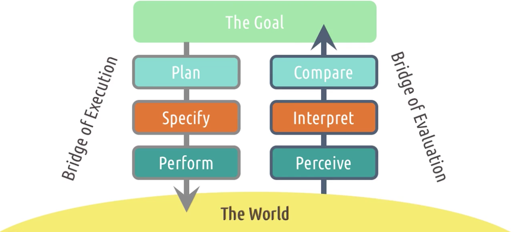

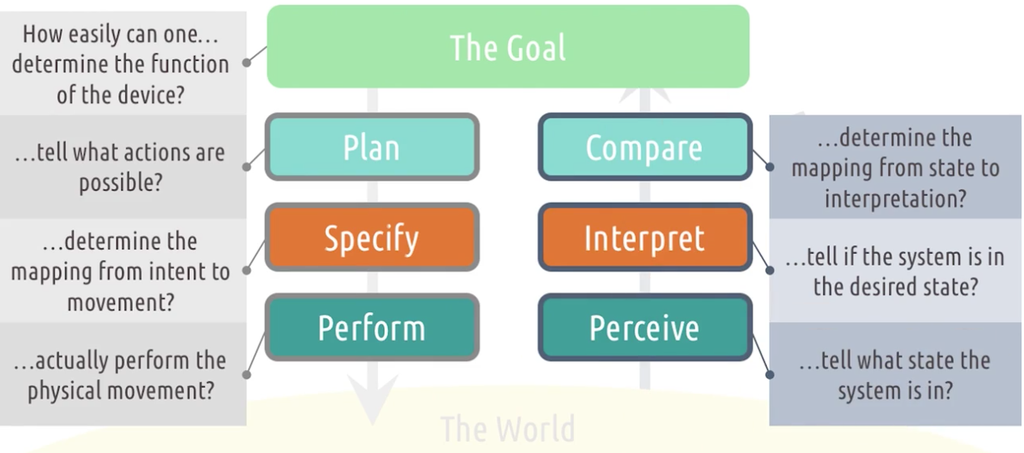

7 questions to bridge the gulf of execution / evaluation:

1. How easily can one determine the function of the device? This relates to the user’s goal: how easily can the user determine that the interface is capable of accomplishing their goal?
2. How easily can one tell what actions are possible? This is important for the user to be able to construct their plan.
3. How easily can one determine the mapping from intention to physical movement?
4. How easily can one actually perform that physical movement?
5. How easily can one tell what state the system is in?
6. How easily can one tell if the system is in the desired state?
7. How easily can one determine the mapping from system state to interpretation?

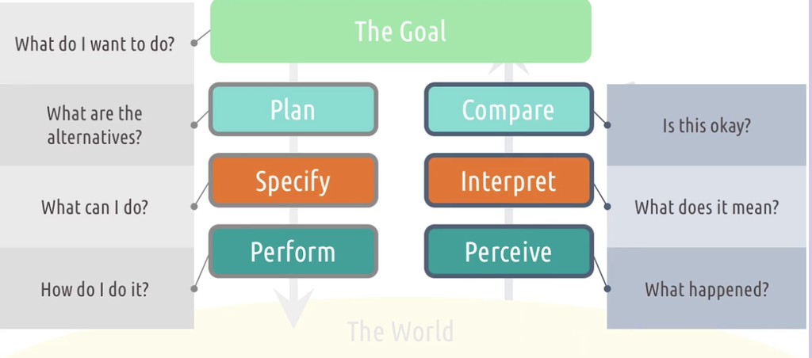

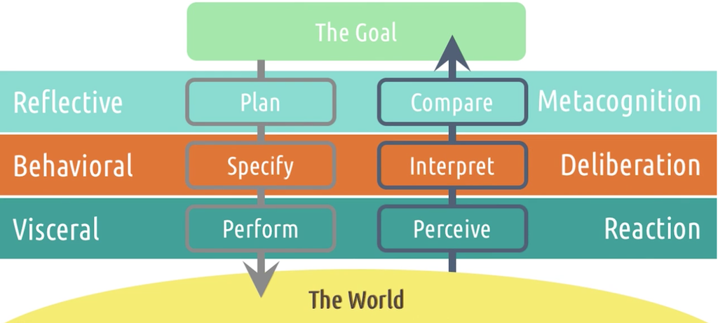

Norman also further articulates this by breaking the process into phases that span both execution and evaluation.

1. The raw action and perception is referred to as visceral: this is the physical act of performing the plan, or the perceiving the outcome.
2. The behavioral area is where we think about what steps to actually take or what we’re seeing from the interface.
3. The reflective area is where we put it in the context of our goal: either translating a goal into a plan, or comparing the interpreted results to the original goal.

Tying it to KBAI:

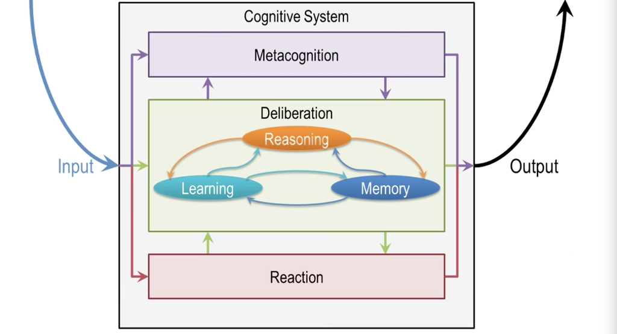

### Feedback Cycles - David's Car

- Designing a system the way a user expects it to be designed is helps them across that gulf of execution (location of ignition)
- Detecting engine on or electrical only - Throws alert telling you how to start the car. The output presented is easy to interpret, and the context in which it is given helps us evaluate pretty quickly.
- So we have some trouble here with the gulf of execution, but the gulf of evaluation is still pretty short.
- Areas of improvement:
  1. We know that the screen can show an alert that the brake needs to be depressed to turn the car on. Why not show that immediately after the car door opens when the car is off?
  2. Ignition sound - Differ the sound based on whether the car turned on, rather than using same sound.

### Design Challenge - Credit Card Readers

What is the problem with the framing of the problem?

The right answer is: We shouldn't be thinking just about swiping or inserting a card, we should be thinking about the general purchasing process.

### Conclusion

1. We discussed feedback cycles’ incredible ubiquity in other fields and discussions.
2. We talked about gulfs of execution, the distance between knowing what they want to accomplish and actually executing the steps to accomplish it.
3. We talked about gulfs of evaluation, the distance between making some change in a system and evaluating whether or not the goal was accomplished.
4. We introduced the seven questions we need to ask to bridge those gulfs.

## 3.1 Intro to Methods

## 3.2 Ethics and Human Research

## 3.3 Needfinding and Requirements Gathering

## 2.3 Direct Manipulation

## 2.4 Human Abilities

## 3.4 Design Alternatives

## 2.5 Design Principles and Heuristics

## 2.6 Mental Models and Representations

## 3.5 Prototyping

## 2.7 Task Analysis

## 2.8 Distributed Cognition

## 3.6 Evaluation

## 2.9 Interfaces and Politics

## 2.10 Conclusion to Principles

## 3.7 HCI and Agile Development

## 3.8 Conclusion to Methods

## 4.1 Applications: Technology

## 4.2 Applications: Ideas

## 4.3 Applications: Domains

## 5.1 Course Recap

## 5.2 Related Fields

## 5.3 Next Steps